# MACHINE LEARNING - INDIVIDUAL PROJECT

## DESCRIPTON

This dataset is composed of 1400 samples with 20 features each. The first column is the sample id. The second column in the dataset represents the label. There are 3 possible values for the labels. The remaining columns are numeric features.

Your task is the following: assuming that you want to classify this data with Logistic Regression (implemented by sklearn.linear_model.LogisticRegression), you should determine whether applying PCA to this dataset is useful, and if so what number of components you would choose to use. At the end of the analysis, you should have chosen an optimal strategy, including the optimal set of parameters for the classifier: write this choice explicitly in the conclusions of your notebook.

Your notebook should detail the procedure you have used to choose the optimal parameters (graphs are a good idea when possible/sensible).

The notebook will be evaluated not only based on the final results, but also on the procedure employed, which should balance practical considerations (one may not be able to exhaustively explore all possible combinations of the parameters) with the desire for achieving the best possible performance in the least amount of time.

Bonus points may be assigned for particularly clean/nifty code and/or well- presented results.

You are also free to attempt other strategies beyond the one in the assignment (which however is mandatory!).

# LIBRARIES

```python
!pip install numpy
!pip install matplotlib
!pip install scikit-learn
```

```python
import sys
import sklearn
import pandas as pd
import numpy as np
import matplotlib.pyplot as plt
import torch
import torch.nn as nn
import torch.optim as optim
import tqdm
import copy
import seaborn as sns
%matplotlib inline
sns.set(color_codes=True)


from scipy import stats
from scipy.stats import randint
from sklearn import metrics
from sklearn.metrics import accuracy_score, confusion_matrix, precision_score, recall_score
from sklearn.pipeline import Pipeline
from sklearn.preprocessing import StandardScaler
from sklearn.decomposition import PCA
from sklearn.model_selection import GridSearchCV
from sklearn.model_selection import train_test_split, cross_val_score, RandomizedSearchCV
from sklearn.linear_model import LogisticRegression, LogisticRegressionCV

from sklearn.model_selection import cross_val_score
from sklearn.ensemble import RandomForestClassifier
from sklearn.metrics import classification_report, confusion_matrix, accuracy_score
```

# DATA ANALYSIS

First of all, We started analyzing all the dataset and the insight behind it. From the description of the assigment We know that in this dataset there are 3 possible values for the labels. Having this information is important both for data analysis and classification.

```python
df = pd.read_csv("mldata_0003185670.csv", index_col=0)
print(df.head)
print("Dataframe dimensions:", np.shape(df))
```

```
<bound method NDFrame.head of       label  feature_1  feature_2  feature_3  feature_4  feature_5  feature_6  \
0         1   0.980339   1.926477   1.378063  -1.153223  -1.885846   1.547944
1         0   2.471725   0.609026   1.175815   1.110727  -0.754307  -0.728089
2         0  -0.839336  -2.416658  -0.064935  -0.292845   0.384957  -0.604078
3         0  -5.685401  -2.270432   1.165372  -3.566786   2.250789   1.709217
4         2  -0.179870  -0.582669   1.349349  -1.829358   0.143990   0.971339
...     ...        ...        ...        ...        ...        ...        ...
1395      1  -0.684028  -0.709234   0.228956   0.526174  -0.557927  -0.047139
1396      0  -2.455903   0.919609  -3.537574  -1.215232   1.248184   1.747050
1397      1  -0.622377   4.820688   2.210061  -0.416684  -3.172649   0.396926
1398      0  -2.542953   0.494258  -2.119386   3.021649   0.179518  -1.380700
1399      1  -0.128458   0.362371   1.005993   0.589890   1.266168   0.148668

      feature_7  feature_8  feature_9  ...  feature_11  feature_12  \
0     -0.254102  -3.326287   1.316955  ...   -3.288893    2.074789
```

[output cut: 39 more lines]

Since we have duplicates column in position 0 and 1 (given by the sample id) I proceded removing one of them in order to have a new dataset with 21 columns. The first column is for the labels, the others for the features.

```python
display(df)
```

|  | label | feature_1 | feature_2 | feature_3 | feature_4 | feature_5 | feature_6 | feature_7 | feature_8 | feature_9 | ... | feature_11 | feature_12 | feature_13 | feature_14 | feature_15 | feature_16 | feature_17 | feature_18 | feature_19 | feature_20 |
| --- | --- | --- | --- | --- | --- | --- | --- | --- | --- | --- | --- | --- | --- | --- | --- | --- | --- | --- | --- | --- | --- |
| 0 | 1 | 0.980339 | 1.926477 | 1.378063 | -1.153223 | -1.885846 | 1.547944 | -0.254102 | -3.326287 | 1.316955 | ... | -3.288893 | 2.074789 | -3.226050 | 3.865833 | 1.165665 | -0.965112 | 1.199996 | 2.790103 | 0.384710 | -1.454569 |
| 1 | 0 | 2.471725 | 0.609026 | 1.175815 | 1.110727 | -0.754307 | -0.728089 | 1.525473 | -0.297223 | -0.518853 | ... | -0.601914 | 0.607169 | -2.241252 | 2.655087 | -1.198816 | 1.162772 | 1.410902 | -0.240155 | 1.134484 | 2.662741 |
| 2 | 0 | -0.839336 | -2.416658 | -0.064935 | -0.292845 | 0.384957 | -0.604078 | 1.821477 | 2.946059 | 0.529494 | ... | 4.083177 | 0.071861 | 4.042353 | -0.260135 | 1.803363 | -0.766237 | 1.530115 | 0.212302 | 2.970812 | -1.441609 |
| 3 | 0 | -5.685401 | -2.270432 | 1.165372 | -3.566786 | 2.250789 | 1.709217 | -1.628876 | -0.450970 | 1.189523 | ... | 4.251464 | 0.277438 | -0.914312 | 0.315260 | -0.666354 | -2.395820 | 2.032139 | -1.744835 | -3.383232 | -4.909843 |
| 4 | 2 | -0.179870 | -0.582669 | 1.349349 | -1.829358 | 0.143990 | 0.971339 | -0.301082 | -0.207738 | -0.721092 | ... | 1.416618 | -2.375466 | -0.796339 | 1.571620 | 1.198311 | 0.127533 | 1.375838 | 0.534421 | -0.182492 | 0.346747 |
| ... | ... | ... | ... | ... | ... | ... | ... | ... | ... | ... | ... | ... | ... | ... | ... | ... | ... | ... | ... | ... | ... |
| 1395 | 1 | -0.684028 | -0.709234 | 0.228956 | 0.526174 | -0.557927 | -0.047139 | -3.664565 | -0.291804 | -1.341281 | ... | -1.731128 | -0.095013 | 2.026618 | -1.866076 | -0.490108 | -4.510603 | -1.545560 | -0.367116 | 2.859044 | 0.812536 |
| 1396 | 0 | -2.455903 | 0.919609 | -3.537574 | -1.215232 | 1.248184 | 1.747050 | -0.099551 | -0.550796 | 0.584322 | ... | 1.001978 | 0.287177 | -0.325851 | 1.955640 | -2.463190 | 4.761320 | -1.228377 | -1.242399 | 0.169292 | -3.031237 |
| 1397 | 1 | -0.622377 | 4.820688 | 2.210061 | -0.416684 | -3.172649 | 0.396926 | 0.298437 | -6.281930 | -3.529423 | ... | -1.523709 | -3.245694 | -2.979737 | -1.550145 | -1.548118 | 2.576249 | -4.611799 | -1.101992 | 5.508258 | -1.664003 |
| 1398 | 0 | -2.542953 | 0.494258 | -2.119386 | 3.021649 | 0.179518 | -1.380700 | 2.735792 | -1.207071 | 1.877979 | ... | -1.237217 | -0.114075 | 0.099538 | -0.568136 | -0.217854 | -0.581684 | -0.312877 | 1.378794 | 0.544925 | -1.956336 |
| 1399 | 1 | -0.128458 | 0.362371 | 1.005993 | 0.589890 | 1.266168 | 0.148668 | -2.953695 | -4.410477 | -1.005314 | ... | -2.145242 | -2.242668 | 0.894983 | -0.848205 | 3.590137 | 0.447059 | -0.920907 | -2.034614 | -4.083084 | 1.575268 |

1400 rows × 21 columns

```python
df.describe()
```

|  | label | feature_1 | feature_2 | feature_3 | feature_4 | feature_5 | feature_6 | feature_7 | feature_8 | feature_9 | ... | feature_11 | feature_12 | feature_13 | feature_14 | feature_15 | feature_16 | feature_17 | feature_18 | feature_19 | feature_20 |
| --- | --- | --- | --- | --- | --- | --- | --- | --- | --- | --- | --- | --- | --- | --- | --- | --- | --- | --- | --- | --- | --- |
| count | 1400.000000 | 1400.000000 | 1400.000000 | 1400.000000 | 1400.000000 | 1400.000000 | 1400.000000 | 1400.000000 | 1400.000000 | 1400.000000 | ... | 1400.000000 | 1400.000000 | 1400.000000 | 1400.000000 | 1400.000000 | 1400.000000 | 1400.000000 | 1400.000000 | 1400.000000 | 1400.000000 |
| mean | 1.001429 | -0.270777 | -0.215384 | 0.286825 | 0.007230 | -0.130585 | 0.226098 | -0.188399 | 0.085363 | 0.464907 | ... | 0.249738 | -0.291347 | 0.160605 | 0.522431 | -0.033056 | -0.180409 | 0.274499 | 0.755572 | 0.043734 | -0.008962 |
| std | 0.825781 | 1.724489 | 1.552143 | 1.781872 | 2.021185 | 1.549432 | 1.342778 | 1.863583 | 2.476777 | 1.388237 | ... | 1.900126 | 1.653808 | 1.483316 | 1.635692 | 1.795831 | 2.201463 | 1.544140 | 1.692632 | 2.076576 | 2.441606 |
| min | 0.000000 | -8.325212 | -5.717915 | -6.767329 | -6.696632 | -4.992742 | -4.298457 | -7.147904 | -10.302654 | -4.422079 | ... | -5.527079 | -5.284930 | -4.561847 | -5.432941 | -7.662299 | -7.217566 | -5.873525 | -4.616002 | -6.970454 | -8.793707 |
| 25% | 0.000000 | -1.392985 | -1.228770 | -0.895494 | -1.373442 | -1.164816 | -0.727095 | -1.443739 | -1.546308 | -0.486149 | ... | -0.987764 | -1.374901 | -0.864069 | -0.581047 | -1.274992 | -1.723858 | -0.719645 | -0.358762 | -1.314701 | -1.661958 |
| 50% | 1.000000 | -0.235219 | -0.295449 | 0.312629 | -0.041799 | -0.207282 | 0.212372 | -0.176319 | 0.131811 | 0.471670 | ... | 0.219057 | -0.283562 | 0.187921 | 0.523197 | -0.099909 | -0.145000 | 0.280007 | 0.787920 | 0.047625 | 0.039232 |
| 75% | 2.000000 | 0.951121 | 0.826736 | 1.415447 | 1.300165 | 0.988855 | 1.100450 | 1.130258 | 1.680296 | 1.340044 | ... | 1.400749 | 0.753026 | 1.213514 | 1.633149 | 1.193112 | 1.273222 | 1.265851 | 1.958995 | 1.487574 | 1.491973 |
| max | 2.000000 | 5.205050 | 5.279405 | 6.241341 | 8.493153 | 5.090628 | 4.964401 | 6.053254 | 8.000788 | 5.791523 | ... | 6.534001 | 5.593316 | 4.286648 | 6.397793 | 5.915891 | 6.643459 | 6.043330 | 6.040174 | 6.868458 | 8.458188 |

8 rows × 21 columns

By the last code we can see that the dataset (obviously) is not standardize

```python
df.head()
```

|  | label | feature_1 | feature_2 | feature_3 | feature_4 | feature_5 | feature_6 | feature_7 | feature_8 | feature_9 | ... | feature_11 | feature_12 | feature_13 | feature_14 | feature_15 | feature_16 | feature_17 | feature_18 | feature_19 | feature_20 |
| --- | --- | --- | --- | --- | --- | --- | --- | --- | --- | --- | --- | --- | --- | --- | --- | --- | --- | --- | --- | --- | --- |
| 0 | 1 | 0.980339 | 1.926477 | 1.378063 | -1.153223 | -1.885846 | 1.547944 | -0.254102 | -3.326287 | 1.316955 | ... | -3.288893 | 2.074789 | -3.226050 | 3.865833 | 1.165665 | -0.965112 | 1.199996 | 2.790103 | 0.384710 | -1.454569 |
| 1 | 0 | 2.471725 | 0.609026 | 1.175815 | 1.110727 | -0.754307 | -0.728089 | 1.525473 | -0.297223 | -0.518853 | ... | -0.601914 | 0.607169 | -2.241252 | 2.655087 | -1.198816 | 1.162772 | 1.410902 | -0.240155 | 1.134484 | 2.662741 |
| 2 | 0 | -0.839336 | -2.416658 | -0.064935 | -0.292845 | 0.384957 | -0.604078 | 1.821477 | 2.946059 | 0.529494 | ... | 4.083177 | 0.071861 | 4.042353 | -0.260135 | 1.803363 | -0.766237 | 1.530115 | 0.212302 | 2.970812 | -1.441609 |
| 3 | 0 | -5.685401 | -2.270432 | 1.165372 | -3.566786 | 2.250789 | 1.709217 | -1.628876 | -0.450970 | 1.189523 | ... | 4.251464 | 0.277438 | -0.914312 | 0.315260 | -0.666354 | -2.395820 | 2.032139 | -1.744835 | -3.383232 | -4.909843 |
| 4 | 2 | -0.179870 | -0.582669 | 1.349349 | -1.829358 | 0.143990 | 0.971339 | -0.301082 | -0.207738 | -0.721092 | ... | 1.416618 | -2.375466 | -0.796339 | 1.571620 | 1.198311 | 0.127533 | 1.375838 | 0.534421 | -0.182492 | 0.346747 |

5 rows × 21 columns

## Data cleaning

In order to be sure that we do not have any null values and that type is equal for features and labels, we will proceed with a simple check

```python
#check if I have some null values
null_count = (df.isnull().sum()).sum()
print('Number of null values:', null_count)
```

```
Number of null values: 0
```

```python
#check if dtype is the same
df.info()
```

```
<class 'pandas.core.frame.DataFrame'>
Index: 1400 entries, 0 to 1399
Data columns (total 21 columns):
 #   Column      Non-Null Count  Dtype
---  ------      --------------  -----
 0   label       1400 non-null   int64
 1   feature_1   1400 non-null   float64
 2   feature_2   1400 non-null   float64
 3   feature_3   1400 non-null   float64
 4   feature_4   1400 non-null   float64
 5   feature_5   1400 non-null   float64
 6   feature_6   1400 non-null   float64
 7   feature_7   1400 non-null   float64
 8   feature_8   1400 non-null   float64
 9   feature_9   1400 non-null   float64
 10  feature_10  1400 non-null   float64
 11  feature_11  1400 non-null   float64
 12  feature_12  1400 non-null   float64
 13  feature_13  1400 non-null   float64
 14  feature_14  1400 non-null   float64
 15  feature_15  1400 non-null   float64
 16  feature_16  1400 non-null   float64
 17  feature_17  1400 non-null   float64
 18  feature_18  1400 non-null   float64
 19  feature_19  1400 non-null   float64
 20  feature_20  1400 non-null   float64
dtypes: float64(20), int64(1)
memory usage: 240.6 KB
```

Each features is float type, each label is integer

Another useful check is to see if recurrence of each labels is balanced because this can may affect our models prediction.

```python
df['label'].value_counts()
```

```
label
2    478
0    476
1    446
Name: count, dtype: int64
```

Hopefully, we can see that the frequency of each labels is almost the same, i.e. we have a balanced label partition.

## Data exploration

Next step is to separate columns corresponding to the features and the column corresponding to the labels and starting analyzing them.

```python
#split features and labels
X = df.iloc[:, 1:]
y = df.iloc[:, 0]

print(X.shape)
print(len(y))
```

```
(1400, 20)
1400
```

Let's now see distribution of raw features

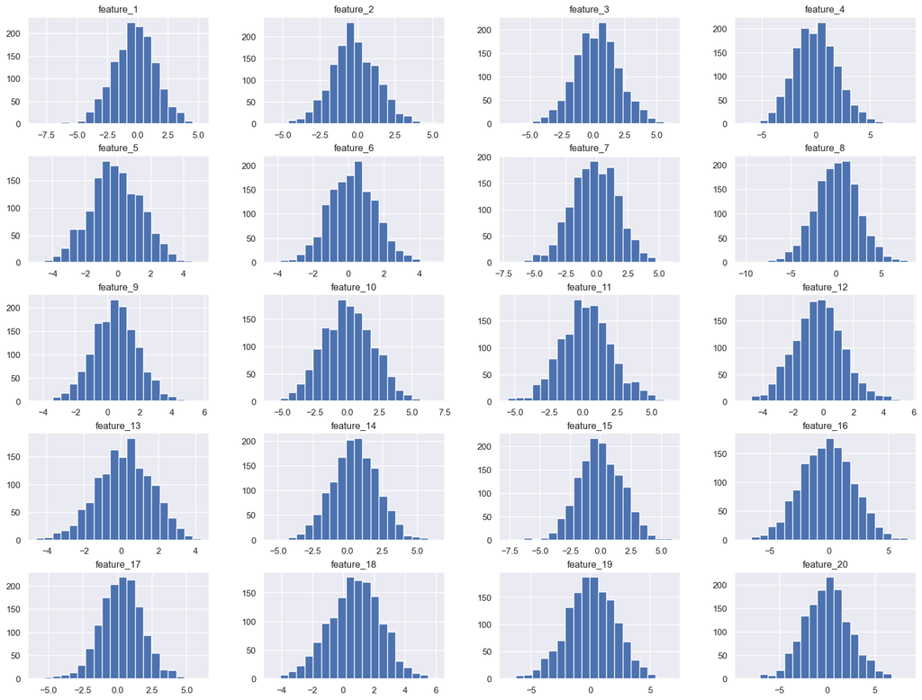

```python
#show histogram of each features
X.hist(bins=20, figsize=(20,15))
#plt.suptitle('Distribution of Features', fontsize=20, fontweight='bold')
plt.show()
```

By these histogram we can see that maybe a data scaling would be better in order to analyze in a more precise our data

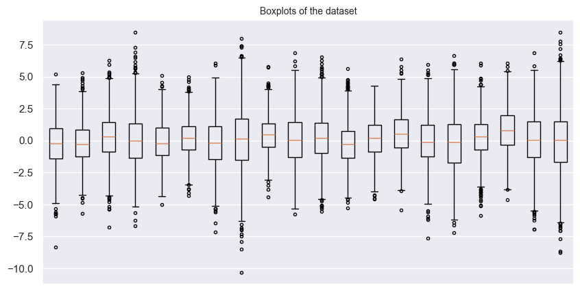

```python
#show boxplots of each features
cnames = list(X)
fig, ax = plt.subplots(figsize=(10,5))
ax.boxplot(df[cnames], flierprops={'marker': '.'})
ax.set_title('Boxplots of the dataset', fontdict={'fontsize': 10})
ax.set_xticks([])
plt.show()
```

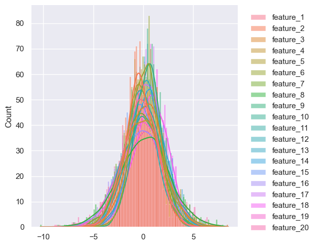

```python
sns.displot(X.iloc[:,:20], kde=True)
```

As the previous plots suggest, we proceed by standardizing our features, that is subctraing the mean and dividing by the standard deviation. We proceed splitting our data set (both features and labels) in train and test and then scaling the train and test features since are the ones that we are going to use in our classification. In this way our datset is splitted in a random way having 80% of the samples for training and the remaining 20% for testing

```python
#split the dataset in training and testing
X_train, X_test, y_train, y_test = train_test_split(X, y, test_size=0.2, random_state=42, stratify=y)
```

We can also see the frequency of the labels both in training and testing

```python
for i in range(3):
    print(f'number of datapoints of class {i} in train: {sum(1 if j==i else 0 for j in y_train)}')

for i in range(3):
    print(f'number of datapoints of class {i} in test: {sum(1 if j==i else 0 for j in y_test)}')
```

```
number of datapoints of class 0 in train: 381
number of datapoints of class 1 in train: 357
number of datapoints of class 2 in train: 382
number of datapoints of class 0 in test: 95
number of datapoints of class 1 in test: 89
number of datapoints of class 2 in test: 96
```

```python
X_train
```

|  | feature_1 | feature_2 | feature_3 | feature_4 | feature_5 | feature_6 | feature_7 | feature_8 | feature_9 | feature_10 | feature_11 | feature_12 | feature_13 | feature_14 | feature_15 | feature_16 | feature_17 | feature_18 | feature_19 | feature_20 |
| --- | --- | --- | --- | --- | --- | --- | --- | --- | --- | --- | --- | --- | --- | --- | --- | --- | --- | --- | --- | --- |
| 1172 | -2.567320 | -0.403925 | 0.352488 | -0.196148 | -1.097413 | -0.222602 | -1.762303 | -1.112944 | 1.040495 | 0.986945 | -0.493899 | -0.574603 | 0.087929 | -2.888857 | -1.980502 | -4.096655 | 1.759009 | 1.361010 | 1.541731 | -1.611190 |
| 829 | -1.453820 | 1.527774 | -0.208101 | 0.645847 | 0.124473 | -1.258802 | 0.229178 | 0.193119 | 1.287098 | 0.124828 | -0.988541 | -1.212452 | -1.060398 | 0.204985 | -0.884942 | 0.222472 | -1.291477 | 1.044711 | 2.973494 | -0.432723 |
| 917 | -3.079429 | 0.055891 | 0.247794 | 1.418549 | 4.234005 | 2.399016 | -2.312161 | 0.662741 | -0.253677 | 1.933204 | -1.640836 | 0.481433 | 0.397122 | 1.303531 | -0.781520 | 2.483909 | -1.341214 | 0.044590 | -2.849175 | -0.232905 |
| 173 | 3.208896 | -1.094969 | -0.313111 | 4.427148 | 0.224034 | 0.615522 | 0.425880 | -0.875026 | -1.074582 | -1.723535 | -0.067398 | -0.762354 | -2.790739 | 2.143056 | -2.740057 | 4.159429 | 0.039559 | 2.128457 | 0.838883 | 0.469472 |
| 990 | 0.566262 | 1.492979 | 4.930699 | 0.301115 | -2.416062 | 2.430638 | -1.847730 | -2.376935 | 2.527730 | 2.811931 | -0.590061 | 1.377368 | -0.864684 | 1.139167 | -1.019234 | -1.306263 | -1.083009 | 1.524627 | -4.884733 | -0.715656 |
| ... | ... | ... | ... | ... | ... | ... | ... | ... | ... | ... | ... | ... | ... | ... | ... | ... | ... | ... | ... | ... |
| 907 | -2.060389 | -2.064000 | 0.687740 | 2.276530 | -0.541966 | 0.697125 | -3.011716 | -2.135437 | 0.500624 | -0.020696 | 0.301079 | -1.537665 | -1.766675 | 2.054387 | -1.425401 | -1.884972 | -0.772589 | 1.903885 | -1.252201 | 1.092372 |
| 502 | 0.445136 | -1.451381 | -2.430221 | -1.086865 | 0.932738 | 0.556873 | -0.524490 | 2.531944 | 2.154223 | 2.487451 | 1.131361 | 1.171034 | 1.675999 | 1.682539 | -0.360725 | -2.602116 | 3.740453 | -0.972017 | -0.950925 | -1.009276 |
| 680 | -2.532475 | -0.459345 | -0.964000 | 0.668468 | 2.763077 | -0.750552 | -0.413993 | -1.386051 | -0.512833 | -0.236520 | -1.366796 | -3.531691 | -0.768185 | 0.986829 | 0.203752 | 4.086906 | -0.670721 | 2.249473 | -0.278434 | 2.577731 |
| 492 | -0.544745 | 2.569331 | -2.038524 | -3.121523 | -1.233580 | 0.567311 | 2.033015 | 1.668207 | 0.343377 | -0.009957 | 1.597897 | 1.838652 | -1.259316 | 1.089376 | -1.479827 | -1.362860 | -1.060537 | -1.323087 | 1.618421 | -3.092323 |
| 98 | 1.883219 | 1.522570 | 1.243873 | 2.611976 | -2.631355 | 1.577969 | 2.052299 | -1.185883 | 1.436566 | -1.082866 | 1.268940 | -1.665796 | -1.311709 | 4.763249 | -0.873439 | 1.898533 | 2.672543 | 3.908573 | 0.748961 | 2.246581 |

1120 rows × 20 columns

```python
X_test
```

|  | feature_1 | feature_2 | feature_3 | feature_4 | feature_5 | feature_6 | feature_7 | feature_8 | feature_9 | feature_10 | feature_11 | feature_12 | feature_13 | feature_14 | feature_15 | feature_16 | feature_17 | feature_18 | feature_19 | feature_20 |
| --- | --- | --- | --- | --- | --- | --- | --- | --- | --- | --- | --- | --- | --- | --- | --- | --- | --- | --- | --- | --- |
| 993 | -2.087828 | -1.367001 | 2.131303 | -1.273161 | 0.302490 | -1.274295 | -2.452647 | -4.828413 | 0.349948 | 1.064840 | 0.665606 | -1.395811 | 0.691806 | -1.465145 | -0.584218 | -1.745214 | -0.168878 | 3.297240 | -2.697304 | 1.987885 |
| 1271 | -0.914574 | 0.777542 | 0.931130 | 0.374052 | 0.750242 | 0.702528 | -1.243369 | -0.143505 | 0.682550 | 3.170868 | 1.294040 | 0.800380 | 0.755458 | 2.747271 | -1.099515 | 0.169879 | -4.332344 | -0.023561 | -1.078215 | 0.113902 |
| 440 | -0.649968 | 1.447869 | 0.671149 | 1.667292 | 2.283888 | 0.312450 | -4.254741 | -0.749934 | 0.172297 | -2.379004 | -2.520519 | -2.721357 | 1.747205 | -1.959655 | 0.871292 | 2.503834 | -0.618262 | -1.459602 | -2.757918 | 3.238129 |
| 534 | -2.757421 | 2.417241 | 1.728043 | -2.551805 | -1.601963 | 2.987518 | -2.523031 | -5.467715 | 0.332043 | -1.773841 | -0.943209 | 1.909371 | 0.568030 | -0.895246 | 1.690979 | -3.491722 | 1.239869 | 2.446417 | -1.925859 | -3.093440 |
| 1051 | 2.921832 | 1.977753 | -0.031309 | -0.957136 | -0.630488 | 1.497423 | 2.943894 | 1.963610 | -0.352581 | -2.308402 | 2.574076 | 2.868364 | -2.180578 | 4.026159 | -2.036661 | 0.307600 | 2.009492 | 0.912275 | 0.742758 | -0.460354 |
| ... | ... | ... | ... | ... | ... | ... | ... | ... | ... | ... | ... | ... | ... | ... | ... | ... | ... | ... | ... | ... |
| 140 | -3.142300 | -1.062432 | -0.795766 | -4.150740 | 0.728877 | 2.123061 | -0.957359 | 1.628688 | 4.255758 | 1.238852 | 3.148558 | -1.030865 | 1.429114 | -0.623938 | 0.873481 | 0.784401 | 1.275109 | 0.152019 | -2.991397 | -6.816577 |
| 92 | -0.390255 | -0.050885 | 0.863349 | 2.226676 | 1.364982 | 1.010385 | -1.787644 | -1.536815 | -0.593346 | -0.373665 | 1.783183 | -1.151466 | 0.711164 | 0.720632 | -2.144519 | -0.700567 | 0.986722 | 2.307575 | 0.315974 | 0.865862 |
| 464 | -2.243623 | -0.350708 | -0.212635 | -1.269200 | -1.086869 | 2.191393 | -2.736381 | 0.743683 | -0.561235 | -0.286858 | -1.340018 | -0.985387 | 0.142138 | -0.966549 | -0.687813 | -0.338779 | 1.007051 | -0.691565 | -0.467235 | 0.722057 |
| 844 | 4.392533 | -2.496719 | -1.344058 | -1.649485 | 1.018305 | 0.178265 | 0.335196 | 5.312515 | -1.708975 | 0.216354 | 2.710803 | 1.070149 | 1.598198 | 1.982424 | -3.004126 | 2.165493 | 2.722094 | -1.072127 | -2.027920 | 5.966426 |
| 72 | 3.488183 | 0.824381 | 1.160741 | -1.049651 | -1.068472 | 0.383708 | -3.081552 | -4.527204 | 0.249669 | -3.508226 | 3.841075 | -2.959019 | 0.226907 | 0.039968 | 0.835851 | 0.104898 | -0.132956 | 0.502700 | -0.157035 | -2.033214 |

280 rows × 20 columns

```python
#standardization of X_train
scaler = StandardScaler()
X_train_scaled = pd.DataFrame(scaler.fit_transform(X_train), columns= X_train.columns)
```

```python
#check of the shape of train features and that they had been standardize correctly
print(X_train_scaled.shape)
print(X_train_scaled.mean())
X_train_scaled.describe().round()
```

```
(1120, 20)
feature_1    -6.344132e-18
feature_2    -1.427430e-17
feature_3     2.854859e-17
feature_4    -1.427430e-17
feature_5    -1.110223e-17
feature_6     7.930164e-18
feature_7     1.744636e-17
feature_8     2.537653e-17
feature_9    -1.268826e-17
feature_10    4.758099e-18
feature_11   -6.344132e-18
feature_12   -1.903239e-17
feature_13    7.930164e-18
feature_14    3.013462e-17
feature_15    2.854859e-17
feature_16    2.577303e-17
feature_17    1.427430e-17
feature_18    5.709718e-17
feature_19   -6.344132e-18
feature_20   -1.903239e-17
dtype: float64
```

|  | feature_1 | feature_2 | feature_3 | feature_4 | feature_5 | feature_6 | feature_7 | feature_8 | feature_9 | feature_10 | feature_11 | feature_12 | feature_13 | feature_14 | feature_15 | feature_16 | feature_17 | feature_18 | feature_19 | feature_20 |
| --- | --- | --- | --- | --- | --- | --- | --- | --- | --- | --- | --- | --- | --- | --- | --- | --- | --- | --- | --- | --- |
| count | 1120.0 | 1120.0 | 1120.0 | 1120.0 | 1120.0 | 1120.0 | 1120.0 | 1120.0 | 1120.0 | 1120.0 | 1120.0 | 1120.0 | 1120.0 | 1120.0 | 1120.0 | 1120.0 | 1120.0 | 1120.0 | 1120.0 | 1120.0 |
| mean | -0.0 | -0.0 | 0.0 | -0.0 | -0.0 | 0.0 | 0.0 | 0.0 | -0.0 | 0.0 | -0.0 | -0.0 | 0.0 | 0.0 | 0.0 | 0.0 | 0.0 | 0.0 | -0.0 | -0.0 |
| std | 1.0 | 1.0 | 1.0 | 1.0 | 1.0 | 1.0 | 1.0 | 1.0 | 1.0 | 1.0 | 1.0 | 1.0 | 1.0 | 1.0 | 1.0 | 1.0 | 1.0 | 1.0 | 1.0 | 1.0 |
| min | -5.0 | -4.0 | -4.0 | -3.0 | -3.0 | -3.0 | -4.0 | -4.0 | -4.0 | -3.0 | -3.0 | -3.0 | -3.0 | -4.0 | -4.0 | -3.0 | -4.0 | -3.0 | -3.0 | -4.0 |
| 25% | -1.0 | -1.0 | -1.0 | -1.0 | -1.0 | -1.0 | -1.0 | -1.0 | -1.0 | -1.0 | -1.0 | -1.0 | -1.0 | -1.0 | -1.0 | -1.0 | -1.0 | -1.0 | -1.0 | -1.0 |
| 50% | 0.0 | -0.0 | 0.0 | 0.0 | -0.0 | -0.0 | 0.0 | 0.0 | 0.0 | -0.0 | -0.0 | 0.0 | 0.0 | -0.0 | -0.0 | 0.0 | -0.0 | 0.0 | 0.0 | 0.0 |
| 75% | 1.0 | 1.0 | 1.0 | 1.0 | 1.0 | 1.0 | 1.0 | 1.0 | 1.0 | 1.0 | 1.0 | 1.0 | 1.0 | 1.0 | 1.0 | 1.0 | 1.0 | 1.0 | 1.0 | 1.0 |
| max | 3.0 | 4.0 | 3.0 | 4.0 | 3.0 | 3.0 | 3.0 | 3.0 | 4.0 | 3.0 | 3.0 | 3.0 | 3.0 | 4.0 | 3.0 | 3.0 | 4.0 | 3.0 | 3.0 | 3.0 |

As we can see we have mean 0 and standard deviation 1 for each feature

```python
display(X_train_scaled)
```

|  | feature_1 | feature_2 | feature_3 | feature_4 | feature_5 | feature_6 | feature_7 | feature_8 | feature_9 | feature_10 | feature_11 | feature_12 | feature_13 | feature_14 | feature_15 | feature_16 | feature_17 | feature_18 | feature_19 | feature_20 |
| --- | --- | --- | --- | --- | --- | --- | --- | --- | --- | --- | --- | --- | --- | --- | --- | --- | --- | --- | --- | --- |
| 0 | -1.346174 | -0.139455 | 0.045777 | -0.138629 | -0.625814 | -0.325631 | -0.844982 | -0.466367 | 0.427040 | 0.463576 | -0.390157 | -0.178188 | -0.062425 | -2.087565 | -1.068055 | -1.766919 | 0.966150 | 0.359663 | 0.734740 | -0.665857 |
| 1 | -0.696989 | 1.111210 | -0.264230 | 0.280654 | 0.149832 | -1.083267 | 0.217192 | 0.053686 | 0.607332 | 0.024042 | -0.652739 | -0.564066 | -0.838226 | -0.197300 | -0.463339 | 0.185449 | -1.020565 | 0.176410 | 1.418135 | -0.188743 |
| 2 | -1.644741 | 0.158250 | -0.012119 | 0.665433 | 2.758540 | 1.591211 | -1.138254 | 0.240681 | -0.519130 | 0.946007 | -0.999012 | 0.460679 | 0.146464 | 0.473885 | -0.406254 | 1.207683 | -1.052958 | -0.403029 | -1.361082 | -0.107846 |
| 3 | 2.021437 | -0.586867 | -0.322300 | 2.163608 | 0.213033 | 0.287178 | 0.322105 | -0.371632 | -1.119295 | -0.918308 | -0.163747 | -0.291771 | -2.007231 | 0.986816 | -1.487306 | 1.965065 | -0.153690 | 0.804297 | 0.399264 | 0.176518 |
| 4 | 0.480746 | 1.088682 | 2.577532 | 0.108990 | -1.462885 | 1.614332 | -0.890545 | -0.969668 | 1.514359 | 1.394008 | -0.441205 | 1.002691 | -0.706003 | 0.373463 | -0.537465 | -0.505582 | -0.884795 | 0.454458 | -2.332674 | -0.303292 |
| ... | ... | ... | ... | ... | ... | ... | ... | ... | ... | ... | ... | ... | ... | ... | ... | ... | ... | ... | ... | ... |
| 1115 | -1.050627 | -1.214260 | 0.231171 | 1.092676 | -0.273220 | 0.346844 | -1.511368 | -0.873507 | 0.032340 | -0.050150 | 0.031860 | -0.760809 | -1.315381 | 0.932640 | -0.761656 | -0.767175 | -0.682625 | 0.674187 | -0.598831 | 0.428705 |
| 1116 | 0.410128 | -0.817624 | -1.493064 | -0.582175 | 0.662914 | 0.244296 | -0.184784 | 0.984967 | 1.241288 | 1.228579 | 0.472618 | 0.877865 | 1.010464 | 0.705450 | -0.173988 | -1.091344 | 2.256621 | -0.992018 | -0.455029 | -0.422166 |
| 1117 | -1.325859 | -0.175337 | -0.682243 | 0.291919 | 1.824803 | -0.711651 | -0.125849 | -0.575114 | -0.708600 | -0.160184 | -0.853537 | -1.967131 | -0.640809 | 0.280388 | 0.137586 | 1.932283 | -0.616281 | 0.874409 | -0.134042 | 1.030066 |
| 1118 | -0.166986 | 1.785559 | -1.276456 | -1.595362 | -0.712252 | 0.251928 | 1.179285 | 0.641041 | -0.082624 | -0.044675 | 0.720281 | 1.281753 | -0.972613 | 0.343042 | -0.791698 | -0.531166 | -0.870159 | -1.195416 | 0.771345 | -1.265506 |
| 1119 | 1.248549 | 1.107841 | 0.538713 | 1.259717 | -1.599551 | 0.990888 | 1.189570 | -0.495410 | 0.716608 | -0.591676 | 0.545653 | -0.838325 | -1.008010 | 2.587692 | -0.456990 | 0.943076 | 1.561115 | 1.835638 | 0.356343 | 0.895997 |

1120 rows × 20 columns

```python
X_test_scaled =  pd.DataFrame(scaler.transform(X_test), columns= X_test.columns)
```

```python
#check of the shape of test features and that they had been standardize correctly
print(X_test_scaled.shape)
print(X_test_scaled.mean())
X_test_scaled.describe().round()
```

```
(280, 20)
feature_1    -0.036294
feature_2    -0.086931
feature_3     0.047323
feature_4    -0.186771
feature_5    -0.060385
feature_6     0.012220
feature_7    -0.027633
feature_8     0.053895
feature_9     0.031134
feature_10    0.027868
feature_11    0.023030
feature_12   -0.034139
feature_13   -0.066627
feature_14   -0.016744
feature_15    0.034375
feature_16    0.016677
feature_17   -0.003398
feature_18    0.044460
feature_19    0.098657
feature_20   -0.085900
dtype: float64
```

|  | feature_1 | feature_2 | feature_3 | feature_4 | feature_5 | feature_6 | feature_7 | feature_8 | feature_9 | feature_10 | feature_11 | feature_12 | feature_13 | feature_14 | feature_15 | feature_16 | feature_17 | feature_18 | feature_19 | feature_20 |
| --- | --- | --- | --- | --- | --- | --- | --- | --- | --- | --- | --- | --- | --- | --- | --- | --- | --- | --- | --- | --- |
| count | 280.0 | 280.0 | 280.0 | 280.0 | 280.0 | 280.0 | 280.0 | 280.0 | 280.0 | 280.0 | 280.0 | 280.0 | 280.0 | 280.0 | 280.0 | 280.0 | 280.0 | 280.0 | 280.0 | 280.0 |
| mean | -0.0 | -0.0 | 0.0 | -0.0 | -0.0 | 0.0 | -0.0 | 0.0 | 0.0 | 0.0 | 0.0 | -0.0 | -0.0 | -0.0 | 0.0 | 0.0 | -0.0 | 0.0 | 0.0 | -0.0 |
| std | 1.0 | 1.0 | 1.0 | 1.0 | 1.0 | 1.0 | 1.0 | 1.0 | 1.0 | 1.0 | 1.0 | 1.0 | 1.0 | 1.0 | 1.0 | 1.0 | 1.0 | 1.0 | 1.0 | 1.0 |
| min | -2.0 | -3.0 | -3.0 | -2.0 | -2.0 | -3.0 | -3.0 | -2.0 | -3.0 | -2.0 | -3.0 | -3.0 | -3.0 | -3.0 | -2.0 | -3.0 | -4.0 | -3.0 | -2.0 | -3.0 |
| 25% | -1.0 | -1.0 | -1.0 | -1.0 | -1.0 | -1.0 | -1.0 | -1.0 | -1.0 | -1.0 | -1.0 | -1.0 | -1.0 | -1.0 | -1.0 | -1.0 | -1.0 | -1.0 | -1.0 | -1.0 |
| 50% | -0.0 | -0.0 | 0.0 | -0.0 | -0.0 | -0.0 | -0.0 | 0.0 | -0.0 | -0.0 | 0.0 | -0.0 | -0.0 | 0.0 | 0.0 | 0.0 | 0.0 | 0.0 | 0.0 | -0.0 |
| 75% | 1.0 | 1.0 | 1.0 | 0.0 | 1.0 | 1.0 | 1.0 | 1.0 | 1.0 | 1.0 | 1.0 | 1.0 | 1.0 | 1.0 | 1.0 | 1.0 | 1.0 | 1.0 | 1.0 | 1.0 |
| max | 3.0 | 3.0 | 3.0 | 4.0 | 2.0 | 3.0 | 2.0 | 3.0 | 3.0 | 3.0 | 3.0 | 4.0 | 3.0 | 3.0 | 2.0 | 3.0 | 3.0 | 3.0 | 3.0 | 3.0 |

Again, X_test has been standardize correctly since we have mean 0 and standard deviation 1

```python
display(X_test_scaled)
```

|  | feature_1 | feature_2 | feature_3 | feature_4 | feature_5 | feature_6 | feature_7 | feature_8 | feature_9 | feature_10 | feature_11 | feature_12 | feature_13 | feature_14 | feature_15 | feature_16 | feature_17 | feature_18 | feature_19 | feature_20 |
| --- | --- | --- | --- | --- | --- | --- | --- | --- | --- | --- | --- | --- | --- | --- | --- | --- | --- | --- | --- | --- |
| 0 | -1.066624 | -0.762992 | 1.029463 | -0.674943 | 0.262836 | -1.094594 | -1.213183 | -1.945806 | -0.077820 | 0.503289 | 0.225371 | -0.674992 | 0.345550 | -1.217711 | -0.297349 | -0.704001 | -0.289441 | 1.481452 | -1.288593 | 0.791261 |
| 1 | -0.382601 | 0.625477 | 0.365766 | 0.145310 | 0.547067 | 0.350794 | -0.568204 | -0.080353 | 0.165346 | 1.577005 | 0.558977 | 0.653632 | 0.388553 | 1.355976 | -0.581777 | 0.161676 | -3.001016 | -0.442513 | -0.515786 | 0.032562 |
| 2 | -0.228333 | 1.059476 | 0.221996 | 0.789298 | 1.520617 | 0.065582 | -2.174346 | -0.321823 | -0.207701 | -1.252486 | -1.465995 | -1.476905 | 1.058570 | -1.519845 | 0.506047 | 1.216689 | -0.582115 | -1.274509 | -1.317524 | 1.297434 |
| 3 | -1.457006 | 1.687089 | 0.806459 | -1.311663 | -0.946099 | 2.021505 | -1.250723 | -2.200366 | -0.090910 | -0.943956 | -0.628674 | 1.324536 | 0.261928 | -0.869516 | 0.958489 | -1.493472 | 0.628045 | 0.988513 | -0.920375 | -1.265959 |
| 4 | 1.854075 | 1.402546 | -0.166464 | -0.517574 | -0.329413 | 0.931995 | 1.665110 | 0.758666 | -0.591439 | -1.216491 | 1.238489 | 1.904695 | -1.595011 | 2.137347 | -1.099053 | 0.223930 | 1.129284 | 0.099680 | 0.353383 | -0.199930 |
| ... | ... | ... | ... | ... | ... | ... | ... | ... | ... | ... | ... | ... | ... | ... | ... | ... | ... | ... | ... | ... |
| 275 | -1.681395 | -0.565801 | -0.589209 | -2.107875 | 0.533504 | 1.389442 | -0.415658 | 0.625306 | 2.777722 | 0.592006 | 1.543455 | -0.454212 | 0.843670 | -0.703753 | 0.507256 | 0.439457 | 0.650996 | -0.340788 | -1.428966 | -2.773304 |
| 276 | -0.076916 | 0.089118 | 0.328283 | 1.067851 | 0.937301 | 0.575889 | -0.858498 | -0.635146 | -0.767463 | -0.230104 | 0.818640 | -0.527172 | 0.358628 | 0.117748 | -1.158587 | -0.231791 | 0.463176 | 0.908072 | 0.149675 | 0.337000 |
| 277 | -1.157455 | -0.105000 | -0.266737 | -0.672971 | -0.619121 | 1.439404 | -1.364515 | 0.272911 | -0.743986 | -0.185847 | -0.839322 | -0.426699 | -0.025801 | -0.913081 | -0.354530 | -0.068252 | 0.476416 | -0.829533 | -0.224159 | 0.278779 |
| 278 | 2.711513 | -1.494421 | -0.892415 | -0.862339 | 0.717232 | -0.032530 | 0.273738 | 2.092146 | -1.583101 | 0.070705 | 1.311071 | 0.816834 | 0.957901 | 0.888673 | -1.633064 | 1.063750 | 1.593386 | -1.050018 | -0.969089 | 2.402009 |
| 279 | 2.184265 | 0.655803 | 0.492741 | -0.563643 | -0.607442 | 0.117683 | -1.548615 | -1.825870 | -0.151133 | -1.828197 | 1.911080 | -1.620683 | 0.031468 | -0.298122 | 0.486485 | 0.132302 | -0.266046 | -0.137614 | -0.076097 | -0.836716 |

280 rows × 20 columns

## Correlation between features

Another important thing that we can see is the correlation between features. If we find an high correlation between two or more features means that they have an high colinearity, and then maybe a dimensionality reduction can be useful in order to reduce dimensionality and complexity without lacking of information

```python
#correlation between features
correlation = X.corr()
correlation
```

|  | feature_1 | feature_2 | feature_3 | feature_4 | feature_5 | feature_6 | feature_7 | feature_8 | feature_9 | feature_10 | feature_11 | feature_12 | feature_13 | feature_14 | feature_15 | feature_16 | feature_17 | feature_18 | feature_19 | feature_20 |
| --- | --- | --- | --- | --- | --- | --- | --- | --- | --- | --- | --- | --- | --- | --- | --- | --- | --- | --- | --- | --- |
| feature_1 | 1.000000 | 0.173719 | 0.177907 | 0.097634 | -0.048443 | -0.136919 | 0.130458 | -0.030851 | -0.259305 | -0.024285 | -0.003677 | 0.234092 | -0.039398 | 0.284104 | 0.124697 | 0.144524 | -0.044777 | -0.174679 | 0.140385 | 0.139256 |
| feature_2 | 0.173719 | 1.000000 | 0.431409 | -0.167451 | -0.341239 | 0.072967 | -0.006601 | -0.631526 | -0.082154 | -0.137687 | -0.179508 | -0.019784 | -0.301500 | 0.057203 | 0.149757 | 0.007875 | -0.236096 | 0.019995 | 0.069798 | -0.032535 |
| feature_3 | 0.177907 | 0.431409 | 1.000000 | -0.282496 | -0.210566 | 0.164806 | -0.237700 | -0.467866 | -0.162274 | 0.119996 | 0.050063 | -0.014521 | -0.217311 | 0.230669 | 0.231108 | -0.173413 | -0.208380 | 0.190497 | -0.102134 | 0.130014 |
| feature_4 | 0.097634 | -0.167451 | -0.282496 | 1.000000 | 0.048711 | -0.345970 | 0.139860 | -0.075486 | -0.161920 | -0.170341 | -0.180431 | -0.144267 | 0.127162 | -0.134662 | -0.177778 | 0.004033 | -0.070450 | 0.011744 | 0.214045 | 0.266664 |
| feature_5 | -0.048443 | -0.341239 | -0.210566 | 0.048711 | 1.000000 | -0.136984 | -0.113619 | 0.362189 | -0.141534 | 0.258130 | 0.114771 | -0.022433 | 0.299001 | -0.004686 | -0.127123 | 0.304864 | -0.028100 | -0.342476 | -0.339431 | 0.158286 |
| feature_6 | -0.136919 | 0.072967 | 0.164806 | -0.345970 | -0.136984 | 1.000000 | -0.161232 | 0.121764 | 0.171702 | 0.152973 | 0.129910 | 0.217894 | -0.103303 | 0.299991 | 0.044977 | -0.007666 | 0.187226 | 0.036119 | -0.386530 | -0.481199 |
| feature_7 | 0.130458 | -0.006601 | -0.237700 | 0.139860 | -0.113619 | -0.161232 | 1.000000 | 0.364604 | 0.287418 | -0.004491 | 0.259553 | 0.232624 | 0.049547 | 0.020539 | 0.122123 | 0.045803 | 0.290425 | 0.089684 | 0.110542 | -0.371650 |
| feature_8 | -0.030851 | -0.631526 | -0.467866 | -0.075486 | 0.362189 | 0.121764 | 0.364604 | 1.000000 | 0.316934 | 0.235539 | 0.251553 | 0.221962 | 0.322731 | 0.050521 | -0.100528 | 0.075759 | 0.298388 | -0.142586 | -0.032326 | -0.245418 |
| feature_9 | -0.259305 | -0.082154 | -0.162274 | -0.161920 | -0.141534 | 0.171702 | 0.287418 | 0.316934 | 1.000000 | -0.069171 | 0.212778 | 0.177356 | 0.044266 | 0.141391 | 0.118103 | -0.031909 | 0.429185 | 0.238999 | -0.253715 | -0.501974 |
| feature_10 | -0.024285 | -0.137687 | 0.119996 | -0.170341 | 0.258130 | 0.152973 | -0.004491 | 0.235539 | -0.069171 | 1.000000 | -0.146398 | 0.049035 | 0.016808 | 0.167166 | -0.148741 | 0.108428 | -0.353072 | -0.170322 | -0.090356 | -0.040350 |
| feature_11 | -0.003677 | -0.179508 | 0.050063 | -0.180431 | 0.114771 | 0.129910 | 0.259553 | 0.251553 | 0.212778 | -0.146398 | 1.000000 | -0.053959 | 0.171126 | 0.200925 | -0.195227 | -0.121488 | 0.353572 | 0.043672 | -0.061222 | -0.293988 |
| feature_12 | 0.234092 | -0.019784 | -0.014521 | -0.144267 | -0.022433 | 0.217894 | 0.232624 | 0.221962 | 0.177356 | 0.049035 | -0.053959 | 1.000000 | -0.032704 | 0.163079 | -0.030436 | -0.238555 | 0.233960 | -0.102640 | -0.306063 | -0.258886 |
| feature_13 | -0.039398 | -0.301500 | -0.217311 | 0.127162 | 0.299001 | -0.103303 | 0.049547 | 0.322731 | 0.044266 | 0.016808 | 0.171126 | -0.032704 | 1.000000 | -0.447004 | 0.404601 | 0.016473 | 0.012472 | -0.311234 | -0.046825 | -0.052159 |
| feature_14 | 0.284104 | 0.057203 | 0.230669 | -0.134662 | -0.004686 | 0.299991 | 0.020539 | 0.050521 | 0.141391 | 0.167166 | 0.200925 | 0.163079 | -0.447004 | 1.000000 | -0.174867 | 0.159282 | 0.140567 | 0.294765 | -0.076228 | 0.166397 |
| feature_15 | 0.124697 | 0.149757 | 0.231108 | -0.177778 | -0.127123 | 0.044977 | 0.122123 | -0.100528 | 0.118103 | -0.148741 | -0.195227 | -0.030436 | 0.404601 | -0.174867 | 1.000000 | 0.028815 | -0.090744 | -0.201640 | -0.082991 | -0.261397 |
| feature_16 | 0.144524 | 0.007875 | -0.173413 | 0.004033 | 0.304864 | -0.007666 | 0.045803 | 0.075759 | -0.031909 | 0.108428 | -0.121488 | -0.238555 | 0.016473 | 0.159282 | 0.028815 | 1.000000 | -0.206548 | -0.265292 | 0.054529 | 0.072652 |
| feature_17 | -0.044777 | -0.236096 | -0.208380 | -0.070450 | -0.028100 | 0.187226 | 0.290425 | 0.298388 | 0.429185 | -0.353072 | 0.353572 | 0.233960 | 0.012472 | 0.140567 | -0.090744 | -0.206548 | 1.000000 | 0.237431 | -0.162694 | -0.178421 |
| feature_18 | -0.174679 | 0.019995 | 0.190497 | 0.011744 | -0.342476 | 0.036119 | 0.089684 | -0.142586 | 0.238999 | -0.170322 | 0.043672 | -0.102640 | -0.311234 | 0.294765 | -0.201640 | -0.265292 | 0.237431 | 1.000000 | 0.118519 | 0.165229 |
| feature_19 | 0.140385 | 0.069798 | -0.102134 | 0.214045 | -0.339431 | -0.386530 | 0.110542 | -0.032326 | -0.253715 | -0.090356 | -0.061222 | -0.306063 | -0.046825 | -0.076228 | -0.082991 | 0.054529 | -0.162694 | 0.118519 | 1.000000 | 0.095487 |
| feature_20 | 0.139256 | -0.032535 | 0.130014 | 0.266664 | 0.158286 | -0.481199 | -0.371650 | -0.245418 | -0.501974 | -0.040350 | -0.293988 | -0.258886 | -0.052159 | 0.166397 | -0.261397 | 0.072652 | -0.178421 | 0.165229 | 0.095487 | 1.000000 |

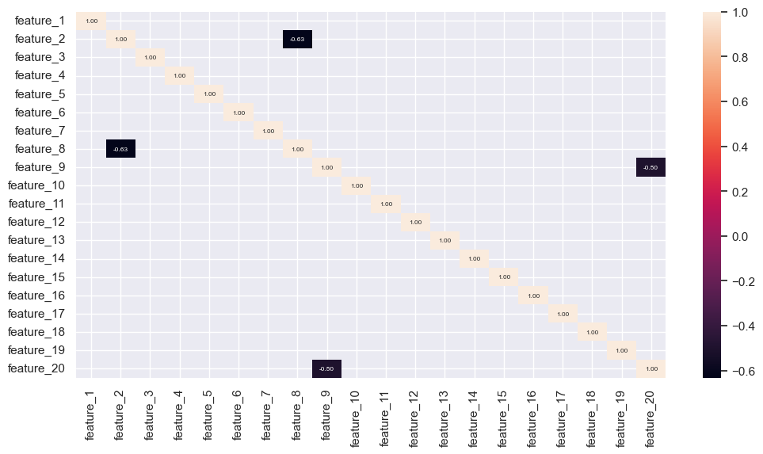

```python
mask = np.abs(correlation) < 0.50
filtered_corr = correlation.mask(mask)

plt.figure(figsize=(12, 6))
sns.heatmap(filtered_corr, annot=True, fmt='.2f', annot_kws={'size': 6})
```

## PCA

The nex part of our data anlysis is about performing a PCA in order to reduce dimensionality and see if it is useful in order to classify our data. The previous plot about correlation of our features make us doubt about its usefulness but we will proceed seeing if it can increase the accuracy of our classifier

```python
def run_PCA(df1, df2, n_components, plot1 = False, plot2 = False):

    X = df1.to_numpy()
    Y = df2.to_numpy()

    # this first paragrapgh of code is about seeing the cumulative variance and the importance of each component in the case we take all the features
    if n_components == 20:
        pca = PCA(n_components = n_components)
        X_train_pca = pca.fit_transform(X)
        X_test_pca = pca.transform(Y)
        print('Original shape:', X.shape)
        print('Original shape:', Y.shape)
        explained_variance = pca.explained_variance_ratio_
        cumulative_variance = np.cumsum(explained_variance)
        for i in range(1,20):
            print(f'Cumulative variance for component {i + 1}: {cumulative_variance[i]}')

    else:
        pca = PCA(n_components = n_components)
        X_train_pca = pca.fit_transform(X)
        X_test_pca = pca.transform(Y)
        print('Reduced shape:', X_train_pca.shape)
        print('Reduced shape:', X_test_pca.shape)
        explained_variance = pca.explained_variance_ratio_
        cumulative_variance = np.cumsum(explained_variance)
        print('Explained variance per component:', explained_variance)
        print('Total explained variance:', sum(explained_variance))


    if plot1:
        var = pca.explained_variance_ratio_[0:n_components]
        labels = ["PC"+str(i+1) for i in range(n_components)]
        plt.figure(figsize=(15,4))
        plt.bar(labels, var)
        plt.xlabel('Pricipal Components')
        plt.ylabel('Proportion of Variance Explained')
        plt.show()

    if plot2:
        fig = plt.figure(figsize=(18,10))

        plt.subplot(2, 2, 1)
        var = pca.explained_variance_ratio_[0:n_components]
        labels = ["PC"+str(i+1) for i in range(n_components)]
        #plt.figure(figsize=(12,4))
        plt.bar(labels, var)
        plt.xlabel('Pricipal Components')
        plt.ylabel('Proportion of Variance Explained')

        plt.subplot(2, 2, 2)
        #cumulative_explained_variance = np.cumsum(explained_variance)
        plt.plot(range(1, len(cumulative_variance) + 1), cumulative_variance, marker='o')
        #plt.axhline(y=0.95, color='grey', linestyle='--')
        #plt.text(1.1, 1, '95% cut-off threshold', color = 'black', fontsize=16)
        plt.xlabel('Number of Components')
        plt.ylabel('Cumulative Explained Variance')
        plt.title('PCA Explained Variance')
        plt.grid()

        plt.show()



    return X_train_pca, X_test_pca
```

First of all we analyze the PCA applied in the maximum number of components (that is all the features, 20) in order to see the cumulative variance expressed by each component and their importance

```
Original shape: (1120, 20)
Original shape: (280, 20)
Cumulative variance for component 2: 0.2976405770914258
Cumulative variance for component 3: 0.40287402983522136
Cumulative variance for component 4: 0.49930155910119617
Cumulative variance for component 5: 0.5787527014246713
Cumulative variance for component 6: 0.6433259974472773
Cumulative variance for component 7: 0.7041742428407628
Cumulative variance for component 8: 0.7558721050789141
Cumulative variance for component 9: 0.8046129502777897
Cumulative variance for component 10: 0.8443802745055767
Cumulative variance for component 11: 0.8788597320206863
Cumulative variance for component 12: 0.9028091623989675
Cumulative variance for component 13: 0.9240403951584755
Cumulative variance for component 14: 0.9428292582515464
Cumulative variance for component 15: 0.9594123535924316
Cumulative variance for component 16: 0.9745922920186787
Cumulative variance for component 17: 0.9889774946073795
Cumulative variance for component 18: 1.0
Cumulative variance for component 19: 1.0
Cumulative variance for component 20: 1.0
```

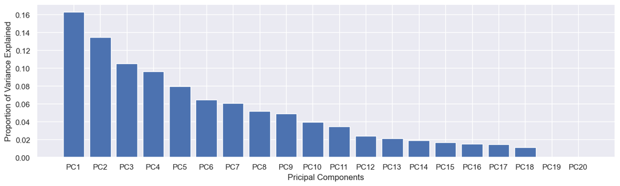

```python
X_train_pca, X_test_pca = run_PCA(X_train_scaled, X_test_scaled, 20, plot1 = True, plot2= False )
```

The cumulative variance explained by the principal components in PCA provides insight into how much of the total variance in the dataset is captured as more components are included. Indeed, we got interesting results:

[output not shown]

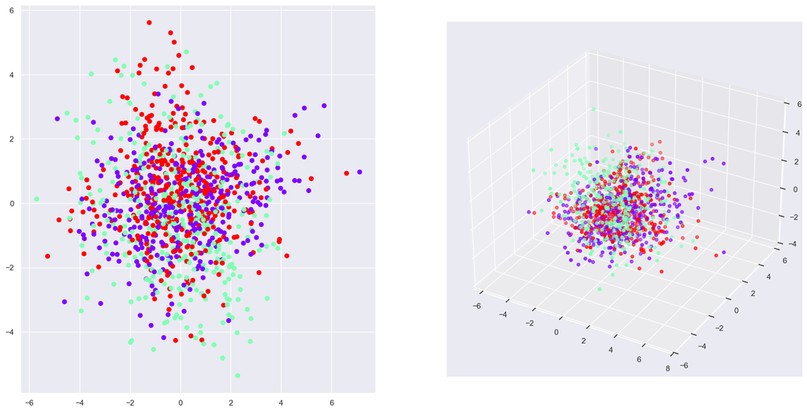

```python
fig = plt.figure(figsize= (20,10))
x1, x2, x3 = [i[0] for i in X_train_pca], [i[1] for i in X_train_pca], [i[2] for i in X_train_pca]
print(x1)
ax0 = fig.add_subplot(1, 2, 1)
ax0.scatter(x1, x2, c=y_train, cmap = 'rainbow')
ax1 = fig.add_subplot(1, 2, 2, projection = '3d')
ax1.scatter(x1, x2, x3, c=y_train, cmap = 'rainbow')

plt.show()
```

We can see by the 2d and 3d plot of the PCA. They are not much informative and we can see by the plot they are not linearly separable

We select the n_components that explain at least 95%. Actually we do not know if choosing this number of components will perform better in our classifier, we start using it and then we will perform a pipe line in order to choose the optimal number of components for our dataset.

```
Reduced shape: (1120, 15)
Reduced shape: (280, 15)
Explained variance per component: [0.16301853 0.13462205 0.10523345 0.09642753 0.07945114 0.0645733
 0.06084825 0.05169786 0.04874085 0.03976732 0.03447946 0.02394943
 0.02123123 0.01878886 0.0165831 ]
Total explained variance: 0.9594123535924318
```

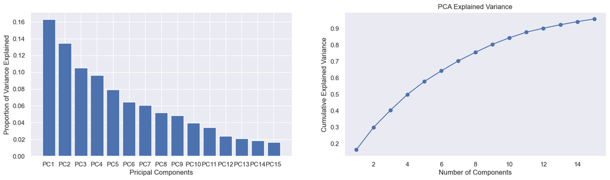

```python
X_train_pca, X_test_pca = run_PCA(X_train_scaled, X_test_scaled, 15, plot1 = False, plot2 = True )
```

```python
print(X_train_pca.shape)
print(X_test_pca.shape)
```

```
(1120, 15)
(280, 15)
```

# LOGISTIC REGRESSION

We now start building our classifier, the Logistic Regression. We will perform it starting with default parameters (apart from the multiclass, since the class of our labels is 3, and solvers that do not conflict with the respective penalty) and then we will Hyper-tune the parameters.

```python
Y = '\033[93m'
E = '\033[0m'

def run_logistic(X, y):
    model = LogisticRegressionCV(random_state=42, multi_class= 'multinomial', cv =5 , max_iter=50000)
    model.fit(X, y)

    logistic_regression_l1 = LogisticRegressionCV( penalty = 'l1', solver= 'saga' , cv = 5, random_state= 42, multi_class= 'multinomial', max_iter=50000)
    logistic_regression_l1.fit(X, y)

    logistic_regression_l2 = LogisticRegressionCV( penalty = 'l2', solver= 'saga' , cv = 5, random_state= 42, multi_class= 'multinomial', max_iter=50000)
    logistic_regression_l2.fit(X, y)

    logistic_regression_el = LogisticRegressionCV( penalty = 'elasticnet', solver= 'saga' , cv = 5, random_state= 42, multi_class= 'multinomial', l1_ratios = [0.2,0.5,0.8], max_iter=50000)
    logistic_regression_el.fit(X, y)

    return model, logistic_regression_l1, logistic_regression_l2, logistic_regression_el


def show_results(y_test, y_pred, model=None):
    if model:
        if type(model) == LogisticRegressionCV:
            #if isinstance(model, LogisticRegression):
            penalty = model.get_params().get('penalty')
            if penalty == 'l1':
                print(f"""L1 Regularization
                        {Y}Accuracy:                   {accuracy_score(y_test, y_pred)}
                        Precision:                  {precision_score(y_test, y_pred, average='weighted')}
                        Recall:                     {recall_score(y_test, y_pred, average='weighted')}{E}
                        Coefficients:               {[i for i in model.coef_[0] if i != 0]}
                        Number of coefficients:     {len([i for i in model.coef_[0] if i != 0])}
                        CV score:                   {[i.mean() for i in list(model.scores_.values())][0]}
                            """)
            elif penalty == 'l2':
                print(f"""L2 Regularization
                        {Y}Accuracy:                   {accuracy_score(y_test, y_pred)}
                        Precision:                  {precision_score(y_test, y_pred, average='weighted')}
                        Recall:                     {recall_score(y_test, y_pred, average='weighted')}{E}
                        Coefficients:               {[i for i in model.coef_[0] if i != 0]}
                        Number of coefficients:     {len([i for i in model.coef_[0] if i != 0])}
                        CV score:                   {[i.mean() for i in list(model.scores_.values())][0]}
                            """)
            elif penalty == 'elasticnet':
                 print(f"""Elasticnet
                        {Y}Accuracy:                   {accuracy_score(y_test, y_pred)}
                        Precision:                  {precision_score(y_test, y_pred, average='weighted')}
                        Recall:                     {recall_score(y_test, y_pred, average='weighted')}{E}
                        Coefficients:               {[i for i in model.coef_[0] if i != 0]}
                        Number of coefficients:     {len([i for i in model.coef_[0] if i != 0])}
                        CV score:                   {[i.mean() for i in list(model.scores_.values())][0]}
                            """)
        else:
            #if isinstance(model, LogisticRegression):
            penalty = model.get_params().get('penalty')
            if penalty == 'l1':
                print(f"""L1 Regularization
                        {Y}Accuracy:                   {accuracy_score(y_test, y_pred)}
                        Precision:                  {precision_score(y_test, y_pred, average='weighted')}
                        Recall:                     {recall_score(y_test, y_pred, average='weighted')}{E}
                        Coefficients:               {[i for i in model.coef_[0] if i != 0]}
                        Number of coefficients:     {len([i for i in model.coef_[0] if i != 0])}
                            """)
            elif penalty == 'l2':
                print(f"""L2 Regularization
                        {Y}Accuracy:                   {accuracy_score(y_test, y_pred)}
                        Precision:                  {precision_score(y_test, y_pred, average='weighted')}
                        Recall:                     {recall_score(y_test, y_pred, average='weighted')}{E}
                        Coefficients:               {[i for i in model.coef_[0] if i != 0]}
                        Number of coefficients:     {len([i for i in model.coef_[0] if i != 0])}
                            """)
            elif penalty == 'elasticnet':
                 print(f"""Elasticnet
                        {Y}Accuracy:                   {accuracy_score(y_test, y_pred)}
                        Precision:                  {precision_score(y_test, y_pred, average='weighted')}
                        Recall:                     {recall_score(y_test, y_pred, average='weighted')}{E}
                        Coefficients:               {[i for i in model.coef_[0] if i != 0]}
                        Number of coefficients:     {len([i for i in model.coef_[0] if i != 0])}
                            """)
    else:
        print(f"""No penalty
                        {Y}Accuracy:                   {accuracy_score(y_test, y_pred)}
                        Precision:                  {precision_score(y_test, y_pred, average='weighted')}
                        Recall:                     {recall_score(y_test, y_pred, average='weighted')}{E}
                            """)
```

## Original Dataset

We start analyzing Logistic Regression performed on the X_train standardize of the raw dataset.

```python
model, model_l1, model_l2, model_el = run_logistic(X_train_scaled, y_train)
```

```python
print('\n\033[4mOriginal dataset\033[0m')
show_results(y_test, model.predict(X_test_scaled))
show_results(y_test, model_l1.predict(X_test_scaled), model_l1)
show_results(y_test, model_l2.predict(X_test_scaled), model_l2)
show_results(y_test, model_el.predict(X_test_scaled), model_el)
```

```
Original dataset
No penalty
                        Accuracy:                   0.625
                        Precision:                  0.6256511231494887
                        Recall:                     0.625

L1 Regularization
                        Accuracy:                   0.6
                        Precision:                  0.5963597655299133
                        Recall:                     0.6
                        Coefficients:               [-0.0032384846255636506, 0.290215931856259, -0.024709305979615234, -0.13508145006673256, -0.01791440797811649, 0.021288433474115753]
                        Number of coefficients:     6
                        CV score:                   0.485625

L2 Regularization
                        Accuracy:                   0.625
                        Precision:                  0.6256511231494887
                        Recall:                     0.625
                        Coefficients:               [-0.01743771800488406, -0.026903687183015827, 0.00569496292040213, 0.04707536669284291, 0.007527802946207797, -0.017393169382374438, 0.012861360520544684, 0.006455284075051616, 0.021851506461824037, 0.0031299956051941908, 0.0292417722137526, -0.004…
                        Number of coefficients:     20
                        CV score:                   0.5450892857142857

Elasticnet
                        Accuracy:                   0.6214285714285714
                        Precision:                  0.6189300997726773
                        Recall:                     0.6214285714285714
                        Coefficients:               [-0.028287720554220935, 0.30428008897043674, -0.0663521023589965, 0.011157494418475697, -0.168909868578745, -0.08134445482204584, 0.06583457747231172]
                        Number of coefficients:     7
                        CV score:                   0.49940476190476185
```

Performance metrics do not perform well, this is justified (as we said before) by the fact that the dataset is not linearly separable and as a consequence classifier do not have an high accuracy.

We can also see the predicted label in contrast to the true ones using confusion matrix.

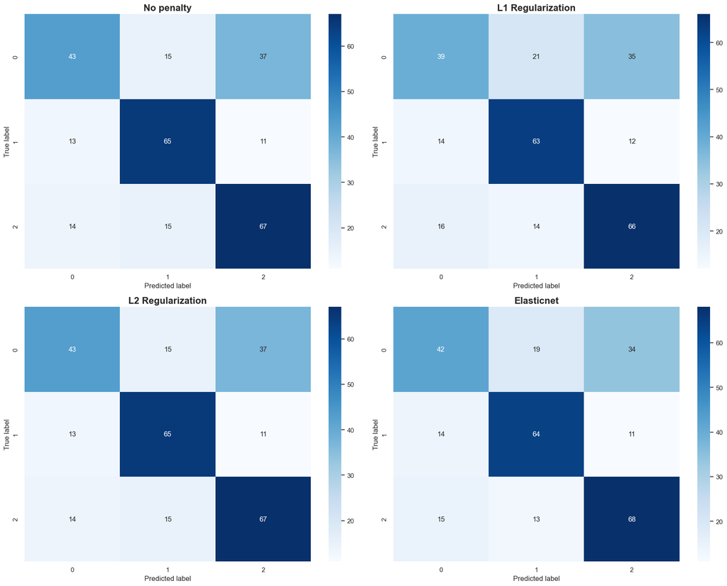

```python
fig = plt.figure(figsize=(18, 14))

plt.subplot(2, 2, 1)

sns.heatmap(confusion_matrix(y_test, model.predict(X_test_scaled)), cmap='Blues', annot=True, fmt='d')
plt.title('No penalty', fontdict={'size': 16, 'weight': 'bold'})
plt.xlabel('Predicted label')
plt.ylabel('True label')

plt.subplot(2, 2, 2)

sns.heatmap(confusion_matrix(y_test, model_l1.predict(X_test_scaled)), cmap='Blues', annot=True, fmt='d')
plt.title('L1 Regularization', fontdict={'size': 16, 'weight': 'bold'})
plt.xlabel('Predicted label')
plt.ylabel('True label')

plt.subplot(2, 2, 3)

sns.heatmap(confusion_matrix(y_test, model_l2.predict(X_test_scaled)), cmap='Blues', annot=True, fmt='d')
plt.title('L2 Regularization', fontdict={'size': 16, 'weight': 'bold'})
plt.xlabel('Predicted label')
plt.ylabel('True label')

plt.subplot(2, 2, 4)

sns.heatmap(confusion_matrix(y_test, model_el.predict(X_test_scaled)), cmap='Blues', annot=True, fmt='d')
plt.title('Elasticnet', fontdict={'size': 16, 'weight': 'bold'})
plt.xlabel('Predicted label')
plt.ylabel('True label')

plt.tight_layout()
plt.show()
```

Let's now try to fine-tune our classifier using GridSearch.

```python
param_grid = [
    {'solver': ['newton-cg', 'sag', 'lbfgs'], 'penalty':['l2'], 'C':[0.001, 0.01, 0.1, 1, 10, 100], 'multi_class': ['ovr', 'multinomial'], 'n_jobs': [-1]},
    {'solver': ['newton-cg', 'sag', 'lbfgs'], 'penalty':[None], 'multi_class': ['ovr', 'multinomial'], 'n_jobs': [-1]},
    {'solver': ['saga'], 'penalty':['l2', 'l1'], 'C':[0.001, 0.01, 0.1, 1, 10, 100], 'multi_class': ['ovr', 'multinomial'], 'n_jobs': [-1]},
    {'solver': ['saga'], 'penalty':[None], 'multi_class': ['ovr', 'multinomial'], 'n_jobs': [-1]},
    {'solver': ['saga'], 'penalty':['elasticnet'], 'C':[0.001, 0.01, 0.1, 1, 10, 100], 'multi_class': ['ovr', 'multinomial'], 'l1_ratio':[0.2,0.5,0.8], 'n_jobs': [-1]},
    {'solver': ['liblinear'], 'penalty':['l1','l2'], 'C':[0.001, 0.01, 0.1, 1, 10, 100], 'multi_class': ['ovr'], 'n_jobs': [1]},
]
```

```python
grid_search = GridSearchCV(estimator=LogisticRegression(random_state=42,max_iter=50000), param_grid=param_grid, cv=5, verbose=1, n_jobs=-1)
grid_search.fit(X_train_scaled, y_train)
```

```
Fitting 5 folds for each of 116 candidates, totalling 580 fits
```

```
GridSearchCV(cv=5,
             estimator=LogisticRegression(max_iter=50000, random_state=42),
             n_jobs=-1,
             param_grid=[{'C': [0.001, 0.01, 0.1, 1, 10, 100],
                          'multi_class': ['ovr', 'multinomial'], 'n_jobs': [-1],
                          'penalty': ['l2'],
                          'solver': ['newton-cg', 'sag', 'lbfgs']},
                         {'multi_class': ['ovr', 'multinomial'], 'n_jobs': [-1],
                          'penalty': [None],
                          'solver': ['newton-cg', 'sag', 'lbfgs']},
                         {'C': [0...
                         {'multi_class': ['ovr', 'multinomial'], 'n_jobs': [-1],
                          'penalty': [None], 'solver': ['saga']},
                         {'C': [0.001, 0.01, 0.1, 1, 10, 100],
                          'l1_ratio': [0.2, 0.5, 0.8],
                          'multi_class': ['ovr', 'multinomial'], 'n_jobs': [-1],
                          'penalty': ['elasticnet'], 'solver': ['saga']},
                         {'C': [0.001, 0.01, 0.1, 1, 10, 100],
                          'multi_class': ['ovr'], 'n_jobs': [1],
                          'penalty': ['l1', 'l2'], 'solver': ['liblinear']}],
             verbose=1)
```

```python
best_params = grid_search.best_params_
print(best_params)
```

```
{'C': 0.001, 'multi_class': 'multinomial', 'n_jobs': -1, 'penalty': 'l2', 'solver': 'newton-cg'}
```

```python
show_results(y_test, grid_search.best_estimator_.predict(X_test_scaled), grid_search.best_estimator_)
print(f'{Y}CV score: {grid_search.best_score_}{E}')
```

```
L2 Regularization
                        Accuracy:                   0.6285714285714286
                        Precision:                  0.6282220218622984
                        Recall:                     0.6285714285714286
                        Coefficients:               [-0.020842034218201806, -0.031299070024992486, 0.007936184719766077, 0.0567462018129295, 0.009145929847693685, -0.020826694349140067, 0.01497899845370388, 0.006754397156351224, 0.02624829469885049, 0.004317412549580422, 0.034748048440377405, -0.005…
                        Number of coefficients:     20

CV score: 0.5660714285714286
```

As we can see, using the best combination of hyperparameter our model perform slightly better bot on the performance metrics both on the cross-validation score

## Dataset Reduced with PCA

Next step is analyzing Logistic Regression performed on the X_train standardize fitted in the PCA, thus with less dimensionality.

```python
model, model_l1, model_l2, model_el = run_logistic(X_train_pca, y_train)
```

```python
print('\n\033[4mDataset reduced with PCA\033[0m')
show_results(y_test, model.predict(X_test_pca))
show_results(y_test, model_l1.predict(X_test_pca), model_l1)
show_results(y_test, model_l2.predict(X_test_pca), model_l2)
show_results(y_test, model_el.predict(X_test_pca), model_el)
```

```
Dataset reduced with PCA
No penalty
                        Accuracy:                   0.625
                        Precision:                  0.6242625275992237
                        Recall:                     0.625

L1 Regularization
                        Accuracy:                   0.6357142857142857
                        Precision:                  0.6338529659651471
                        Recall:                     0.6357142857142857
                        Coefficients:               [0.04700651064466266, 0.12730654959359775, 0.03434503564113735, -0.1062418082578982, -0.12058222525831615, -0.14822638986607425]
                        Number of coefficients:     6
                        CV score:                   0.49249999999999994

L2 Regularization
                        Accuracy:                   0.625
                        Precision:                  0.6242625275992237
                        Recall:                     0.625
                        Coefficients:               [0.02162718963179249, -0.0016849748576336723, -0.05447094441524824, 0.04346581598655743, 0.027469335568600723, 0.027709245447335384, -0.0033582734592286813, 0.01794282185357158, -0.030133847059473834, -0.03428450235752942, -0.033054617225871503, 0.…
                        Number of coefficients:     15
                        CV score:                   0.5449107142857141

Elasticnet
                        Accuracy:                   0.6392857142857142
                        Precision:                  0.6376293995859214
                        Recall:                     0.6392857142857142
                        Coefficients:               [0.05230800788332769, 0.13231631853925171, 0.05165298879155049, -0.11654739909678928, -0.13393447718547458, -0.1573065256436103]
                        Number of coefficients:     6
                        CV score:                   0.5001488095238096
```

Same as before we can also see the predicted label in contrast to the true ones using confusion matrix.

[figure not shown]

```python
fig = plt.figure(figsize=(18,12))

plt.subplot(2, 2, 1)
sns.heatmap(confusion_matrix(y_test, model.predict(X_test_pca)), cmap='Blues', annot=True, fmt='d')
plt.title('No penalty', fontdict={'size': 16, 'weight': 'bold'})
plt.xlabel('Predicted label')
plt.ylabel('True label')

plt.subplot(2, 2, 2)

sns.heatmap(confusion_matrix(y_test, model_l1.predict(X_test_pca)), cmap='Blues', annot=True, fmt='d')
plt.title('L1 Regularization', fontdict={'size': 16, 'weight': 'bold'})
plt.xlabel('Predicted label')
plt.ylabel('True label')

plt.subplot(2, 2, 3)

sns.heatmap(confusion_matrix(y_test, model_l2.predict(X_test_pca)), cmap='Blues', annot=True, fmt='d')
plt.title('L2 Regularization', fontdict={'size': 16, 'weight': 'bold'})
plt.xlabel('Predicted label')
plt.ylabel('True label')

plt.subplot(2, 2, 4)

sns.heatmap(confusion_matrix(y_test, model_l2.predict(X_test_pca)), cmap='Blues', annot=True, fmt='d')
plt.title('Elasticnet', fontdict={'size': 16, 'weight': 'bold'})
plt.xlabel('Predicted label')
plt.ylabel('True label')

plt.tight_layout()
plt.show()
```

Let's now try to fine-tune our classifier.

Differently from what we did in the Original Dataset, here using GridSearch to find best combination of Logistic Regression parameter is not enough, (more precisely it will not be accurate). The best way to proceed is to use a Pipeline in order to choose the optimal combination of Logistic parameters considering also the choice of number of components for the PCA.

```python
estimator = Pipeline([
    ('pca', PCA()),
    ('logi', LogisticRegression(random_state=42, max_iter = 50000))
])
param_grid = [
    {'pca__n_components':[8, 10, 12, 14, 16, 18], 'logi__solver': ['newton-cg', 'sag', 'lbfgs'], 'logi__penalty':['l2'], 'logi__C':[0.001, 0.01, 0.1, 1, 10, 100], 'logi__multi_class': ['ovr', 'multinomial'], 'logi__n_jobs': [-1]},
    {'pca__n_components':[8, 10, 12, 14, 16, 18], 'logi__solver': ['newton-cg', 'sag', 'lbfgs'], 'logi__penalty':[None], 'logi__multi_class': ['ovr', 'multinomial'], 'logi__n_jobs': [-1]},
    {'pca__n_components':[8, 10, 12, 14, 16, 18], 'logi__solver': ['saga'], 'logi__penalty':['l2', 'l1'], 'logi__C':[0.001, 0.01, 0.1, 1, 10, 100], 'logi__multi_class': ['ovr', 'multinomial'], 'logi__n_jobs': [-1]},
    {'pca__n_components':[8, 10, 12, 14, 16, 18], 'logi__solver': ['saga'], 'logi__penalty':[None], 'logi__multi_class': ['ovr', 'multinomial'], 'logi__n_jobs': [-1]},
    {'pca__n_components':[8, 10, 12, 14, 16, 18], 'logi__solver': ['saga'], 'logi__penalty':['elasticnet'], 'logi__C':[0.001, 0.01, 0.1, 1, 10, 100], 'logi__multi_class': ['ovr', 'multinomial'], 'logi__l1_ratio':[0.2,0.5,0.8], 'logi__n_jobs': [-1]},
    {'pca__n_components':[8, 10, 12, 14, 16, 18], 'logi__solver': ['liblinear'], 'logi__penalty':['l1','l2'], 'logi__C':[0.001, 0.01, 0.1, 1, 10, 100], 'logi__multi_class': ['ovr'], 'logi__n_jobs': [1]},
]
```

```python
grid_search_red = GridSearchCV(estimator= estimator, param_grid=param_grid, cv=5, verbose=1, n_jobs=-1)
grid_search_red.fit(X_train_scaled, y_train)
```

```
Fitting 5 folds for each of 696 candidates, totalling 3480 fits
```

```
GridSearchCV(cv=5,
             estimator=Pipeline(steps=[('pca', PCA()),
                                       ('logi',
                                        LogisticRegression(max_iter=50000,
                                                           random_state=42))]),
             n_jobs=-1,
             param_grid=[{'logi__C': [0.001, 0.01, 0.1, 1, 10, 100],
                          'logi__multi_class': ['ovr', 'multinomial'],
                          'logi__n_jobs': [-1], 'logi__penalty': ['l2'],
                          'logi__solver': ['newton-cg', 'sag', 'lbfgs'],
                          'pca__n_components': [8, 10, 12, 14, 16, 18]},
                         {'l...
                          'logi__l1_ratio': [0.2, 0.5, 0.8],
                          'logi__multi_class': ['ovr', 'multinomial'],
                          'logi__n_jobs': [-1], 'logi__penalty': ['elasticnet'],
                          'logi__solver': ['saga'],
                          'pca__n_components': [8, 10, 12, 14, 16, 18]},
                         {'logi__C': [0.001, 0.01, 0.1, 1, 10, 100],
                          'logi__multi_class': ['ovr'], 'logi__n_jobs': [1],
                          'logi__penalty': ['l1', 'l2'],
                          'logi__solver': ['liblinear'],
                          'pca__n_components': [8, 10, 12, 14, 16, 18]}],
             verbose=1)
```

```python
best_params_red = grid_search_red.best_params_
print(best_params_red)
```

```
{'logi__C': 0.001, 'logi__multi_class': 'multinomial', 'logi__n_jobs': -1, 'logi__penalty': 'l2', 'logi__solver': 'newton-cg', 'pca__n_components': 16}
```

```python
show_results(y_test, grid_search_red.best_estimator_.predict(X_test_scaled),grid_search_red.best_estimator_.get_params()['steps'][1][1])
print(f'{Y}CV score: {grid_search_red.best_score_}{E}')
```

```
L2 Regularization
                        Accuracy:                   0.625
                        Precision:                  0.6229227405247814
                        Recall:                     0.625
                        Coefficients:               [0.024575447945207513, -0.00183729036865009, -0.06371576073879512, 0.05086512283956176, 0.03313774097974336, 0.03329191196598295, -0.004082603071280861, 0.02173297342744636, -0.03664644004451132, -0.04212408744983824, -0.04049968073869434, 0.014814…
                        Number of coefficients:     16

CV score: 0.5660714285714287
```

The results provided are very similar to the previous model on the Original Dataset.

# RANDOM FOREST (EXTRA)

## Why Random Forest?

I chose Random Forest as another classifier in order to perform a features selection. After performing Random Forest I will select the most important features according to this classifier and use them to perform again Logistic Regression. In this way at the end of the analysis I will compare the results and performances of Logistic Regression obtained by the three different strategies that I have used:

- Logistic Regression on the raw dataset (Scaling X_train and X_test)
- Logistic Regression using data obtained by the PCA (X_train_pca, X_test_pca)
- Logistic Regression using data obtained by features selection of Random Forest

## Classification

We start building our classifier both on the Original Dataset (X_train standardize) and on the Dataset reduced with PCA (X_train standardize obtained by dimensionality reduction), in order to see in which dataset the model perform in a better way

```python
# Decision Tree Classifier on original dataset
clf = RandomForestClassifier(random_state=42)
clf = clf.fit(X_train_scaled, y_train)
y_pred = clf.predict(X_test_scaled)
print('\n\033[4mOriginal Dataset\033[0m')
print(f"""{Y}Accuracy of the model: {metrics.accuracy_score(y_test, y_pred)}{E}""")
print("Classification Report:\n", classification_report(y_test, y_pred))

#inefficient, but easy to implement
gscv = GridSearchCV(RandomForestClassifier(), param_grid={'random_state': [42]}, cv=5, n_jobs=-1)
gscv.fit(X_train_scaled, y_train)
print(f'{Y}CV score: {gscv.best_score_}{E}')


# Decision Tree Classifier on reduced dataset
clf_red = RandomForestClassifier(random_state=42)
clf_red = clf_red.fit(X_train_pca, y_train)
y_pred_red = clf_red.predict(X_test_pca)
print('\n\033[4mDataset reduced with PCA\033[0m')
print(f"""{Y}Accuracy of the model: {metrics.accuracy_score(y_test, y_pred_red)}{E}""")
print("Classification Report:\n", classification_report(y_test, y_pred_red))

#inefficient, but easy to implement
gscv = GridSearchCV(clf, param_grid={'random_state': [42]}, cv=5, n_jobs=-1)
gscv.fit(X_train_pca, y_train)
print(f'{Y}CV score: {gscv.best_score_}{E}')
```

```
Original Dataset
Accuracy of the model: 0.7571428571428571
Classification Report:
               precision    recall  f1-score   support

           0       0.76      0.76      0.76        95
           1       0.77      0.75      0.76        89
           2       0.74      0.76      0.75        96

    accuracy                           0.76       280
   macro avg       0.76      0.76      0.76       280
weighted avg       0.76      0.76      0.76       280

CV score: 0.7366071428571427

Dataset reduced with PCA
Accuracy of the model: 0.7642857142857142
Classification Report:
               precision    recall  f1-score   support

           0       0.73      0.79      0.76        95
           1       0.79      0.82      0.81        89
           2       0.78      0.69      0.73        96

    accuracy                           0.76       280
   macro avg       0.77      0.77      0.76       280
weighted avg       0.77      0.76      0.76       280

CV score: 0.7473214285714286
```

We can also see the predicted label in contrast to the true ones using confusion matrix.

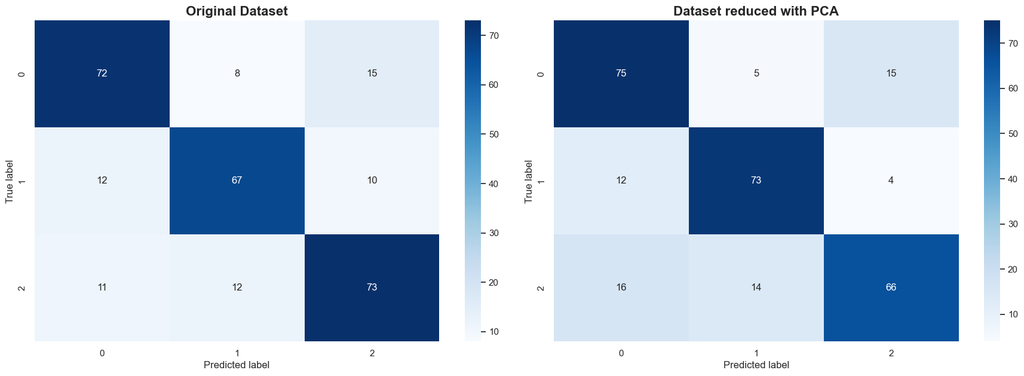

```python
fig = plt.figure(figsize=(18,12))

plt.subplot(2, 2, 1)
sns.heatmap(confusion_matrix(y_test, y_pred), cmap='Blues', annot=True, fmt='d')
plt.title('Original Dataset', fontdict={'size': 16, 'weight': 'bold'})
plt.xlabel('Predicted label')
plt.ylabel('True label')

plt.subplot(2, 2, 2)

sns.heatmap(confusion_matrix(y_test, y_pred_red), cmap='Blues', annot=True, fmt='d')
plt.title('Dataset reduced with PCA', fontdict={'size': 16, 'weight': 'bold'})
plt.xlabel('Predicted label')
plt.ylabel('True label')


plt.tight_layout()
plt.show()
```

## Hyperparameter tuning

Our next step is about trying to improve our model using hyperparameter.

We will do it in the dataset reduced with PCA since we have seen that our model performs better with a lower dimensionality

```python
param_grid = {'n_estimators': [50, 100, 150, 200],
              'max_depth': [20, 30, 40, 50, 60],
              'criterion': ['gini', 'entropy'],
              'min_samples_leaf': [1, 2, 3, 4],
              'min_samples_split': [2, 4, 6]}

# Create a random forest classifier
rf = RandomForestClassifier(random_state=42)

# Use random search to find the best hyperparameters
grid_search_r = GridSearchCV(rf, param_grid = param_grid, cv=5, verbose = 1, n_jobs=-1)

# Fit the random search object to the data
grid_search_r.fit(X_train_pca, y_train)
best_rf = grid_search_r.best_estimator_
print('Best hyperparameters:',  grid_search_r.best_params_)
```

```
Fitting 5 folds for each of 480 candidates, totalling 2400 fits
Best hyperparameters: {'criterion': 'gini', 'max_depth': 30, 'min_samples_leaf': 1, 'min_samples_split': 2, 'n_estimators': 150}
```

```python
# Random Forest on original dataset
rf = RandomForestClassifier(n_estimators=150, min_samples_split=2, min_samples_leaf=1, max_depth=30, criterion='gini', random_state=42)
rf.fit(X_train_pca, y_train)
y_pred = rf.predict(X_test_pca)


print(f"""{Y}Accuracy model: {metrics.accuracy_score(y_test, y_pred)}{E}""")
print("Classification Report:\n", classification_report(y_test, y_pred))
print(f'{Y}CV score: {grid_search_r.best_score_}{E}')
```

```
Accuracy model: 0.7928571428571428
Classification Report:
               precision    recall  f1-score   support

           0       0.75      0.81      0.78        95
           1       0.85      0.83      0.84        89
           2       0.78      0.74      0.76        96

    accuracy                           0.79       280
   macro avg       0.80      0.79      0.79       280
weighted avg       0.79      0.79      0.79       280

CV score: 0.7526785714285714
```

## Features selection

Now we have all the tools for our goal, that is feature selections.

In this part we will proceed analyzing the importance of the features using random forest and then selecting a part of them (a small range that have an 'higher importance') in order to use them in our Logistic Regression

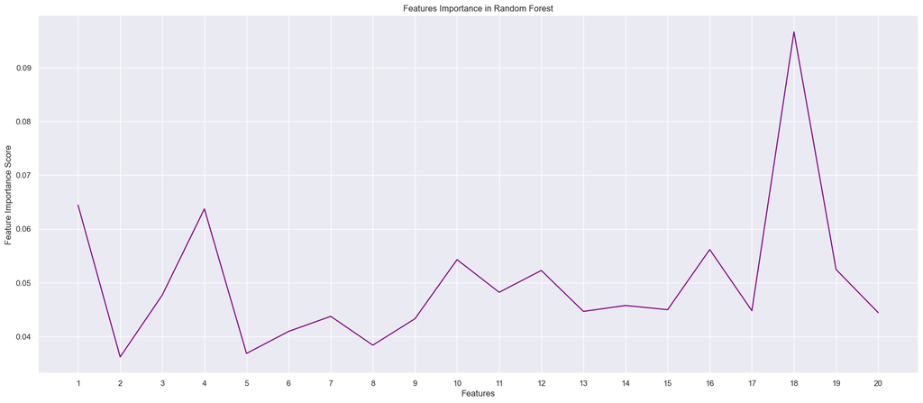

```python
plt.figure(figsize = (22,9))
plt.plot(np.arange(1, 21), clf.feature_importances_, color = 'purple')
plt.xticks(ticks=np.arange(1, 21))
plt.xlabel('Features')
plt.ylabel('Feature Importance Score')
plt.title("Features Importance in Random Forest")
plt.show()
```

```python
most_important = pd.DataFrame(clf.feature_importances_, index=X_train_scaled.columns).rename(columns={0: 'Value'})
most_important
```

|  | Value |
| --- | --- |
| feature_1 | 0.064435 |
| feature_2 | 0.036193 |
| feature_3 | 0.047710 |
| feature_4 | 0.063732 |
| feature_5 | 0.036847 |
| feature_6 | 0.040944 |
| feature_7 | 0.043747 |
| feature_8 | 0.038386 |
| feature_9 | 0.043300 |
| feature_10 | 0.054292 |
| feature_11 | 0.048218 |
| feature_12 | 0.052280 |
| feature_13 | 0.044662 |
| feature_14 | 0.045763 |
| feature_15 | 0.044982 |
| feature_16 | 0.056173 |
| feature_17 | 0.044795 |
| feature_18 | 0.096647 |
| feature_19 | 0.052459 |
| feature_20 | 0.044437 |

We will select only the first 15 features (sorted by importance) in order to have a good comparison to the Dataset reduced with PCA

```python
best_15 = most_important.sort_values(by = 'Value', ascending = False).iloc[:15,:]
best_15
```

|  | Value |
| --- | --- |
| feature_18 | 0.096647 |
| feature_1 | 0.064435 |
| feature_4 | 0.063732 |
| feature_16 | 0.056173 |
| feature_10 | 0.054292 |
| feature_19 | 0.052459 |
| feature_12 | 0.052280 |
| feature_11 | 0.048218 |
| feature_3 | 0.047710 |
| feature_14 | 0.045763 |
| feature_15 | 0.044982 |
| feature_17 | 0.044795 |
| feature_13 | 0.044662 |
| feature_20 | 0.044437 |
| feature_7 | 0.043747 |

```python
X_important = X.loc[:,best_15.index]
```

```python
print(X_important.shape)
```

```
(1400, 15)
```

## Fitting most important features into logistic regression

Our final step will be to perform Logistic Regression using most important features

First of all we need to split train and testing in our new dataset:

```python
X_train, X_test, y_train, y_test = train_test_split(X_important, y, test_size=0.2, random_state=42, stratify=y)
```

Then we standardize both X_train and X_test obtained by the previous split

```python
X_train_scaled = pd.DataFrame(scaler.fit_transform(X_train), columns= X_train.columns)
X_test_scaled =  pd.DataFrame(scaler.transform(X_test), columns= X_test.columns)
```

Finally we perform Logistic Regression

```python
model, model_l1, model_l2, model_el = run_logistic(X_train_scaled, y_train)
```

```python
print('\033[4mLogistic Regression on most important features\033[0m')
show_results(y_test, model.predict(X_test_scaled))
show_results(y_test, model_l1.predict(X_test_scaled), model_l1)
show_results(y_test, model_l2.predict(X_test_scaled), model_l2)
show_results(y_test, model_el.predict(X_test_scaled), model_el)
```

```
Logistic Regression on most important features
No penalty
                        Accuracy:                   0.6392857142857142
                        Precision:                  0.6375306222371441
                        Recall:                     0.6392857142857142

L1 Regularization
                        Accuracy:                   0.6321428571428571
                        Precision:                  0.6300211468909483
                        Recall:                     0.6321428571428571
                        Coefficients:               [0.3590545978598553, -0.17708170550609148, -0.140563059592633, 0.1362301585210231, 0.013169716643580628, 0.029792904943820912]
                        Number of coefficients:     6
                        CV score:                   0.48401785714285706

L2 Regularization
                        Accuracy:                   0.625
                        Precision:                  0.6245740197392983
                        Recall:                     0.625
                        Coefficients:               [0.12690086383293617, -0.06641307514764248, 0.15304063069310447, -0.12862924889748265, 0.027970993559818438, -0.06378191651185518, -0.019703084009523662, 0.09881286940717138, 0.007776239439233052, 0.037369096216829135, -0.05081387096128112, 0.01802…
                        Number of coefficients:     15
                        CV score:                   0.5388392857142857

Elasticnet
                        Accuracy:                   0.6285714285714286
                        Precision:                  0.6274940069459662
                        Recall:                     0.6285714285714286
                        Coefficients:               [0.3206493887384238, -0.13437984331225022, -0.0969489126504284, 0.06778165418086515, 0.013357879782300571]
                        Number of coefficients:     5
                        CV score:                   0.49797619047619046
```

Furthermore we can try to improve our model by searching the best combination of hyperparameters using GridSearch

```python
param_grid = [
    {'solver': ['newton-cg', 'sag', 'lbfgs'], 'penalty':['l2'], 'C':[0.001, 0.01, 0.1, 1, 10, 100], 'multi_class': ['ovr', 'multinomial'], 'n_jobs': [-1]},
    {'solver': ['newton-cg', 'sag', 'lbfgs'], 'penalty':[None], 'multi_class': ['ovr', 'multinomial'], 'n_jobs': [-1]},
    {'solver': ['saga'], 'penalty':['l2', 'l1'], 'C':[0.001, 0.01, 0.1, 1, 10, 100], 'multi_class': ['ovr', 'multinomial'], 'n_jobs': [-1]},
    {'solver': ['saga'], 'penalty':[None], 'multi_class': ['ovr', 'multinomial'], 'n_jobs': [-1]},
    {'solver': ['saga'], 'penalty':['elasticnet'], 'C':[0.001, 0.01, 0.1, 1, 10, 100], 'multi_class': ['ovr', 'multinomial'], 'l1_ratio':[0.2,0.5,0.8], 'n_jobs': [-1]},
    {'solver': ['liblinear'], 'penalty':['l1','l2'], 'C':[0.001, 0.01, 0.1, 1, 10, 100], 'multi_class': ['ovr'], 'n_jobs': [1]},
]
```

```python
grid_search_imp = GridSearchCV(estimator=LogisticRegression(random_state=42,max_iter=50000), param_grid=param_grid, cv=5, verbose=1, n_jobs=-1)
grid_search_imp.fit(X_train_scaled, y_train)
```

```
Fitting 5 folds for each of 116 candidates, totalling 580 fits
```

```
GridSearchCV(cv=5,
             estimator=LogisticRegression(max_iter=50000, random_state=42),
             n_jobs=-1,
             param_grid=[{'C': [0.001, 0.01, 0.1, 1, 10, 100],
                          'multi_class': ['ovr', 'multinomial'], 'n_jobs': [-1],
                          'penalty': ['l2'],
                          'solver': ['newton-cg', 'sag', 'lbfgs']},
                         {'multi_class': ['ovr', 'multinomial'], 'n_jobs': [-1],
                          'penalty': [None],
                          'solver': ['newton-cg', 'sag', 'lbfgs']},
                         {'C': [0...
                         {'multi_class': ['ovr', 'multinomial'], 'n_jobs': [-1],
                          'penalty': [None], 'solver': ['saga']},
                         {'C': [0.001, 0.01, 0.1, 1, 10, 100],
                          'l1_ratio': [0.2, 0.5, 0.8],
                          'multi_class': ['ovr', 'multinomial'], 'n_jobs': [-1],
                          'penalty': ['elasticnet'], 'solver': ['saga']},
                         {'C': [0.001, 0.01, 0.1, 1, 10, 100],
                          'multi_class': ['ovr'], 'n_jobs': [1],
                          'penalty': ['l1', 'l2'], 'solver': ['liblinear']}],
             verbose=1)
```

```python
best_params_imp = grid_search_imp.best_params_
print(best_params_imp)
```

```
{'C': 0.01, 'l1_ratio': 0.2, 'multi_class': 'ovr', 'n_jobs': -1, 'penalty': 'elasticnet', 'solver': 'saga'}
```

```python
#grid_search.best_estimator_.fit(X_train_scaled, y_train)
show_results(y_test, grid_search_imp.best_estimator_.predict(X_test_scaled), grid_search_imp.best_estimator_)
print(f'{Y}CV score: {grid_search_imp.best_score_}{E}')
```

```
Elasticnet
                        Accuracy:                   0.5964285714285714
                        Precision:                  0.5940854119425548
                        Recall:                     0.5964285714285714
                        Coefficients:               [0.15597616346384535, -0.011821446368011912, 0.2039573254053559, -0.13072096202450478, -0.034854484524699, 0.11632286801198011, 0.0002209766761994734, -0.025468854341146638, 0.0010476058696178474]
                        Number of coefficients:     9

CV score: 0.5544642857142857
```

# CONCLUSION

Overall, the different types of Logistic Regression that I have performed give very similar results. The cross-validation score of the best models chosen (through GridSearch, regarding Orignal Dataset and the one using most important features selected by Random Forest, through GridSearch and the use of the pipeline regarding the Dataset reduced with PCA) are almost the same. As far as the performance metrics are concerned, the ones of the Original Dataset are slightly better. For this reason the final model that I decided to choose in order to make prediction is the Logistic Regression performed on the Orginal Dataset (after being improved using hyperparameters) with the following parameters:

```python
print(best_params)
```

```
{'C': 0.001, 'multi_class': 'multinomial', 'n_jobs': -1, 'penalty': 'l2', 'solver': 'newton-cg'}
```

# Prediction

```python
file = pd.read_csv('/Users/raffaelesimbari/Desktop/mldata_0003185670/mldata_0003185670.TEST_FEATURES.csv', index_col='id')
predictions_final = grid_search.best_estimator_.predict(file)
np.savetxt('/Users/raffaelesimbari/Desktop/mldata_0003185670/mldata_0003185670.TEST_labels.txt', predictions_final, fmt='%d', delimiter=',')
```